# Project 1 (visdat/Pokemon)

Michaline Becknell

Feb, 16th

```r
# Load any R Packages you may need using the library function
library(mosaic)
library(tidyverse)
library(visdat)
```

## Package Summary - visdat

visdat for “looking at the data”. It is a package that is used for quick and easy visualization of a new dataframe using simple graphs to help the viewer get a an idea of what they’re working with.

## Dataset Summary - Pokemon

This data set includes 949 rows of Pokemon and 22 columns including the Pokemon’s ID#, height, weight, XP, HP, type, attack points, etc. It was provided by Frank Hull to TidyTuesday in April of 2025.

### *Getting to Know the Data*

These are some functions I used to look at this data set. Even using these exploratory functions, it is hard to get a good idea of data types and missingness.

```r
#summary(pokemon_df)
#dim(pokemon_df)
#favstats(pokemon_df$base_experience)
#colnames(pokemon_df)
```

## Three Functions I Used:

- **Function 1: vis_dat()** creates a graph which pleasantly represents the dataframe, breaking it down into character or numeric data types and showing the missingness in grey.

*Using this function I can tell that while most of my data is numeric, a large portion is character data. I can also see that most of the missingness is in the columns with character data.*

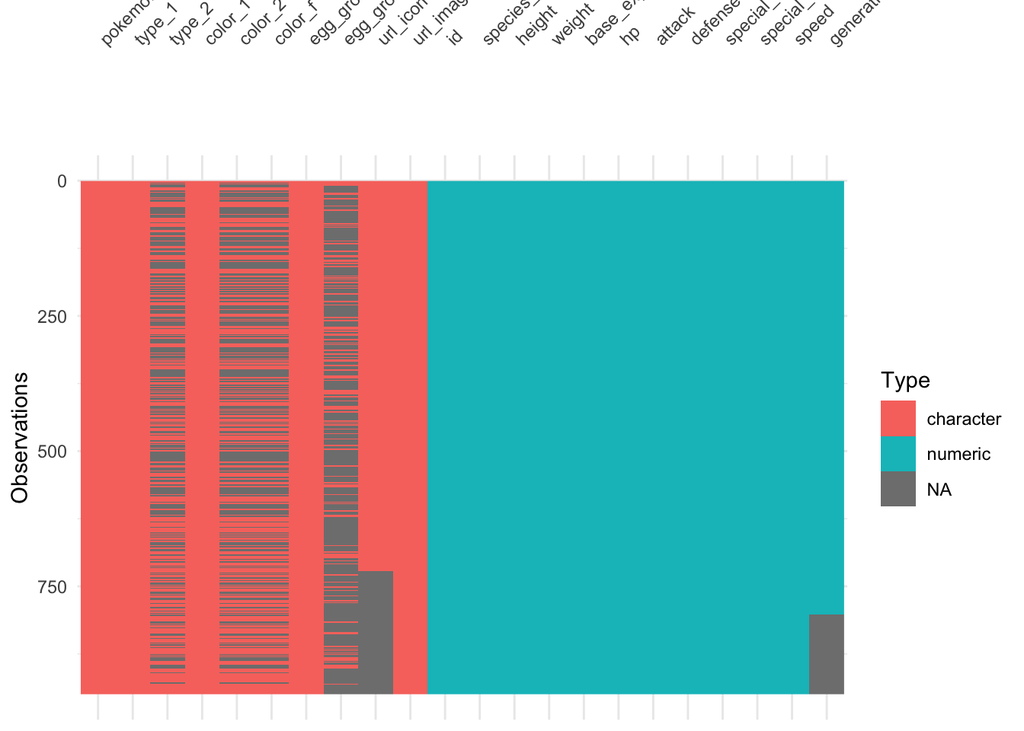

```r
vis_dat(pokemon_df)
```

- **Function 2: vis_miss(pokemon_df)** creates a simple black and great graph showing the missing and present data in my dataframe. It shows the location in the dataframe and the percentages of missing and present data in a simple way.

*Using this function I can tell that most of the data in my table is present, but certain rows such as the color_2, color_f, and egg_group_2 columns are missing quite a bit of data.*

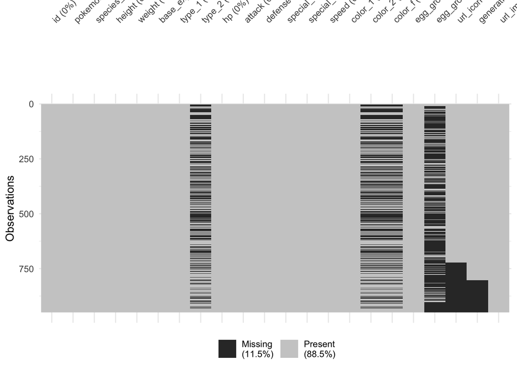

```r
vis_miss(pokemon_df)
```

- **Function 3: vis_cor(pokemon_numeric_subset)** creates a simple graph showing the correlation between several numeric variables which I have placed in a dataframe with numeric-only variables.

*Using this function I am able to easily see that the pokemon_df dataframe has several points of possitive correlation, especially between it’s height and weight, and special_defense/attack and base_experience variables.*

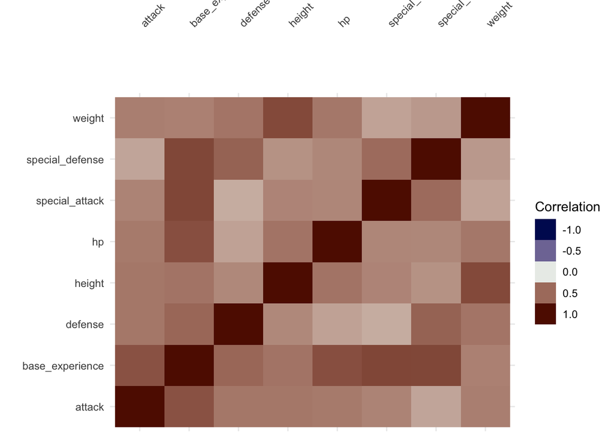

```r
pokemon_numeric_subset = pokemon_df[,c("height","weight","hp","base_experience","attack","special_attack","defense","special_defense")]
vis_cor(pokemon_numeric_subset)
```

## My Thoughts:

Overall, I liked this package. I am a visual learner, so it is helpful to see the data in a simple graphic way. Something like this could help me specify further questions or ways to analyze the data.

This package would be very useful for getting to know a dataset and “looking at the data”. Simple and at-a-glance graphs make it easy to absorb some basic information about data types, variables, missingness, and numeric correlations. This package could be helpful in the future if I want to quickly understand a new dataframe.

Some things that confused me about this package was the vis_cor() function, which does not take character data. I made my own dataframe using a few numeric variables to overcome this. vis_col() also has several other arguments that you can add on. I was confused by all of that extra informatio when I read through the “Help” tab, but I realized that I just had to try it out to understand it.

I also enjoyed going through the TidyTuesday site and looking at all of the interesting data sets. I hope I can find something in there to use for my future projects in the future!

## Dataset Citation:

The pokemon_df dataset was used for this project, added to TidyTuesday in April, 2025:

URL: https://github.com/rfordatascience/tidytuesday/blob/main/data/2025/2025-04-01/readme.md#pokemon_dfcsv

Accessed: Jan 2026

*please let me know if this is cited incorrectly*